# Advanced Machine Learning - Easy Visa Problem Statement¶

```python
#Get the training metrics
confmat(model3, X_train_US, y_train_US)

model3_train_df = model_performance(model3, X_train_US, y_train_US)
model3_train_df
```

|  | Accuracy | Recall | Precision | F1 |
| --- | --- | --- | --- | --- |
| 0 | 1.0 | 1.0 | 1.0 | 1.0 |

|  | Accuracy | Recall | Precision | F1 |
| --- | --- | --- | --- | --- |
| 0 | 0.616824 | 0.621743 | 0.760786 | 0.684273 |

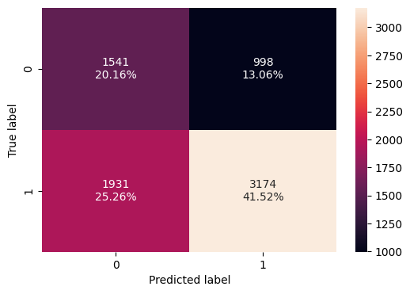

```python
#Get the testing metrics
confmat(model3, X_test, y_test)

model3_test_df = model_performance(model3, X_test, y_test)
model3_test_df
```

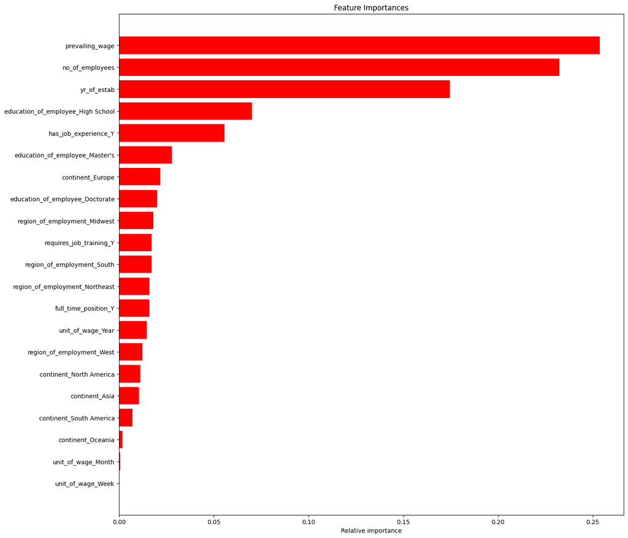

```python
feature_imp_plot(model3,X_train_US)
```

Model4 - Bagging Classifier using original data

```python
model4 = BaggingClassifier(estimator=DecisionTreeClassifier(random_state=1, class_weight='balanced'), n_estimators=100, random_state=1)
model4.fit(X_train, y_train)
```

```
BaggingClassifier(estimator=DecisionTreeClassifier(class_weight='balanced',
                                                   random_state=1),
                  n_estimators=100, random_state=1)
```

```python
#Get the training metrics
confmat(model4, X_train, y_train)

model4_train_df = model_performance(model4, X_train, y_train)
model4_train_df
```

|  | Accuracy | Recall | Precision | F1 |
| --- | --- | --- | --- | --- |
| 0 | 1.0 | 1.0 | 1.0 | 1.0 |

|  | Accuracy | Recall | Precision | F1 |
| --- | --- | --- | --- | --- |
| 0 | 0.719519 | 0.840744 | 0.763294 | 0.800149 |

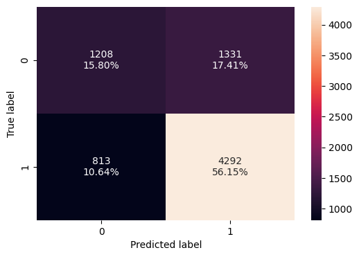

```python
#Get the testing metrics
confmat(model4, X_test, y_test)

model4_test_df = model_performance(model4, X_test, y_test)
model4_test_df
```

Model5 - Bagging Classifier using oversampled data

```python
model5 = BaggingClassifier(estimator=DecisionTreeClassifier(random_state=1, class_weight='balanced'), n_estimators=100, random_state=1)
model5.fit(X_train_OS, y_train_OS)
```

```
BaggingClassifier(estimator=DecisionTreeClassifier(class_weight='balanced',
                                                   random_state=1),
                  n_estimators=100, random_state=1)
```

|  | Accuracy | Recall | Precision | F1 |
| --- | --- | --- | --- | --- |
| 0 | 1.0 | 1.0 | 1.0 | 1.0 |

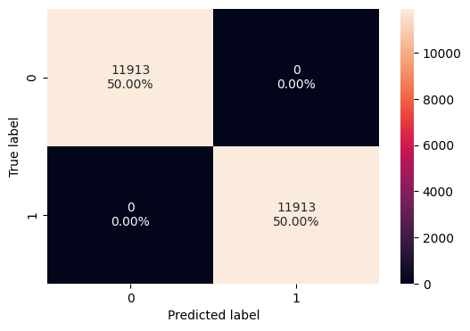

```python
#Get the training metrics
confmat(model5, X_train_OS, y_train_OS)

model5_train_df = model_performance(model5, X_train_OS, y_train_OS)
model5_train_df
```

|  | Accuracy | Recall | Precision | F1 |
| --- | --- | --- | --- | --- |
| 0 | 0.710623 | 0.810382 | 0.768816 | 0.789052 |

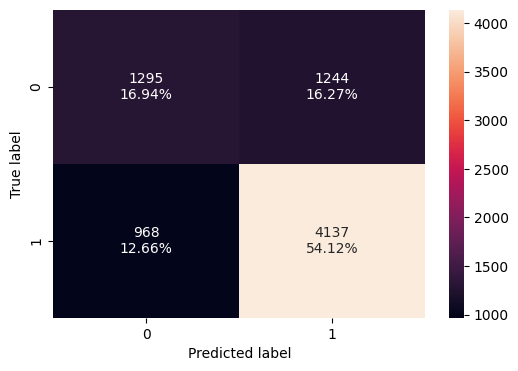

```python
#Get the testing metrics
confmat(model5, X_test, y_test)

model5_test_df = model_performance(model5, X_test, y_test)
model5_test_df
```

Model6 - Bagging Classifier using undersampled data

```python
model6 = BaggingClassifier(estimator=DecisionTreeClassifier(random_state=1, class_weight='balanced'), n_estimators=100, random_state=1)
model6.fit(X_train_US, y_train_US)
```

```
BaggingClassifier(estimator=DecisionTreeClassifier(class_weight='balanced',
                                                   random_state=1),
                  n_estimators=100, random_state=1)
```

```python
#Get the training metrics
confmat(model6, X_train_US, y_train_US)

model6_train_df = model_performance(model6, X_train_US, y_train_US)
model6_train_df
```

|  | Accuracy | Recall | Precision | F1 |
| --- | --- | --- | --- | --- |
| 0 | 1.0 | 1.0 | 1.0 | 1.0 |

|  | Accuracy | Recall | Precision | F1 |
| --- | --- | --- | --- | --- |
| 0 | 0.67203 | 0.667973 | 0.807674 | 0.73121 |

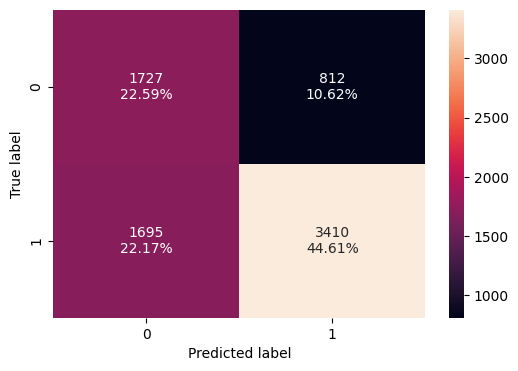

```python
#Get the testing metrics
confmat(model6, X_test, y_test)

model6_test_df = model_performance(model6, X_test, y_test)
model6_test_df
```

Model7 - Random Forest using original data

```python
model7 = RandomForestClassifier(n_estimators=100, random_state=1, class_weight='balanced')
model7.fit(X_train, y_train)
```

```
RandomForestClassifier(class_weight='balanced', random_state=1)
```

```python
#Get the training metrics
confmat(model7, X_train, y_train)

model7_train_df = model_performance(model7, X_train, y_train)
model7_train_df
```

|  | Accuracy | Recall | Precision | F1 |
| --- | --- | --- | --- | --- |
| 0 | 1.0 | 1.0 | 1.0 | 1.0 |

|  | Accuracy | Recall | Precision | F1 |
| --- | --- | --- | --- | --- |
| 0 | 0.727368 | 0.847209 | 0.768343 | 0.805851 |

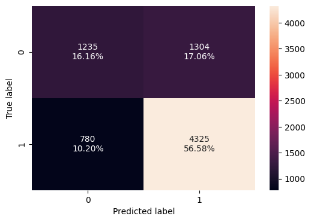

```python
#Get the testing metrics
confmat(model7, X_test, y_test)

model7_test_df = model_performance(model7, X_test, y_test)
model7_test_df
```

Model8 - Random Forest using oversampled data

```python
model8 = RandomForestClassifier(n_estimators=100, random_state=1, class_weight='balanced')
model8.fit(X_train_OS, y_train_OS)
```

```
RandomForestClassifier(class_weight='balanced', random_state=1)
```

|  | Accuracy | Recall | Precision | F1 |
| --- | --- | --- | --- | --- |
| 0 | 0.999958 | 0.999916 | 1.0 | 0.999958 |

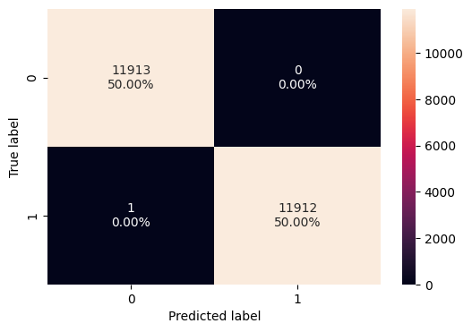

```python
#Get the training metrics
confmat(model8, X_train_OS, y_train_OS)

model8_train_df = model_performance(model8, X_train_OS, y_train_OS)
model8_train_df
```

|  | Accuracy | Recall | Precision | F1 |
| --- | --- | --- | --- | --- |
| 0 | 0.719649 | 0.820568 | 0.773449 | 0.796312 |

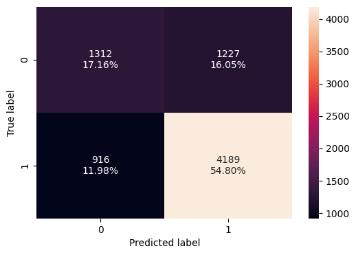

```python
#Get the testing metrics
confmat(model8, X_test, y_test)

model8_test_df = model_performance(model8, X_test, y_test)
model8_test_df
```

Model9 - Random Forest using undersampled data

```python
model9 = RandomForestClassifier(n_estimators=100, random_state=1, class_weight='balanced')
model9.fit(X_train_US, y_train_US)
```

```
RandomForestClassifier(class_weight='balanced', random_state=1)
```

```python
#Get the training metrics
confmat(model9, X_train_US, y_train_US)

model9_train_df = model_performance(model9, X_train_US, y_train_US)
model9_train_df
```

|  | Accuracy | Recall | Precision | F1 |
| --- | --- | --- | --- | --- |
| 0 | 1.0 | 1.0 | 1.0 | 1.0 |

|  | Accuracy | Recall | Precision | F1 |
| --- | --- | --- | --- | --- |
| 0 | 0.677263 | 0.672674 | 0.81182 | 0.735726 |

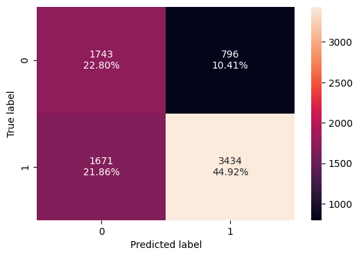

```python
#Get the testing metrics
confmat(model9, X_test, y_test)

model9_test_df = model_performance(model9, X_test, y_test)
model9_test_df
```

```python
## Training performance comparison

models_train_bagging = pd.concat([model1_train_df.T,model2_train_df.T,model3_train_df.T,model4_train_df.T,model5_train_df.T,model6_train_df.T,model7_train_df.T,model8_train_df.T,model9_train_df.T], axis =1)
models_train_bagging.columns = ["DT_Orgdata", "DT_OSdata", "DT_USdata","Bag_Orgdata", "Bag_OSdata", "Bag_USdata","RF_Orgdata", "RF_OSdata", "RF_USdata"]

print(models_train_bagging)
```

```
           DT_Orgdata  DT_OSdata  DT_USdata  Bag_Orgdata  Bag_OSdata  \
Accuracy          1.0        1.0        1.0          1.0         1.0
Recall            1.0        1.0        1.0          1.0         1.0
Precision         1.0        1.0        1.0          1.0         1.0
F1                1.0        1.0        1.0          1.0         1.0

           Bag_USdata  RF_Orgdata  RF_OSdata  RF_USdata
Accuracy          1.0         1.0   0.999958        1.0
Recall            1.0         1.0   0.999916        1.0
Precision         1.0         1.0   1.000000        1.0
F1                1.0         1.0   0.999958        1.0
```

```python
## Testing performance comparison

models_test_bagging = pd.concat([model1_test_df.T,model2_test_df.T,model3_test_df.T,model4_test_df.T,model5_test_df.T,model6_test_df.T,model7_test_df.T,model8_test_df.T,model9_test_df.T], axis =1)
models_test_bagging.columns = ["DT_Orgdata", "DT_OSdata", "DT_USdata","Bag_Orgdata", "Bag_OSdata", "Bag_USdata","RF_Orgdata", "RF_OSdata", "RF_USdata"]

print(models_test_bagging)
```

```
           DT_Orgdata  DT_OSdata  DT_USdata  Bag_Orgdata  Bag_OSdata  \
Accuracy     0.664835   0.657248   0.616824     0.719519    0.710623
Recall       0.742801   0.722821   0.621743     0.840744    0.810382
Precision    0.752232   0.753830   0.760786     0.763294    0.768816
F1           0.747487   0.738000   0.684273     0.800149    0.789052

           Bag_USdata  RF_Orgdata  RF_OSdata  RF_USdata
Accuracy     0.672030    0.727368   0.719649   0.677263
Recall       0.667973    0.847209   0.820568   0.672674
Precision    0.807674    0.768343   0.773449   0.811820
F1           0.731210    0.805851   0.796312   0.735726
```

Observations:

1. Here the training dataset is overfit for all the models.
2. Hence while comparing testing dataset, we can see that the F1 score of Original dataset has better results than oversampled and undersampled.

**Choosing original dataset for Hyperparameter tuning.**

#### HyperParameters Tuning - Bagging

1. model10 - Decision Tree + Original dataset + Hyper parameter tuning (RandomizedSearchCV)
2. model11 - Bagging Classifier + Original dataset + Hyper parameter tuning (RandomizedSearchCV)
3. model12 - Random forest classifier + Original dataset + Hyper parameter tuning (RandomizedSearchCV)

```
Fitting 3 folds for each of 10 candidates, totalling 30 fits
Best Parameters: {'min_samples_split': 40, 'min_samples_leaf': 15, 'min_impurity_decrease': 0.001, 'max_depth': 7, 'criterion': 'entropy'}
F1 Score: 73.08%
   Accuracy    Recall  Precision        F1
0  0.741029  0.812222   0.802455  0.807309
   Accuracy    Recall  Precision        F1
0  0.732208  0.809207   0.793812  0.801436
```

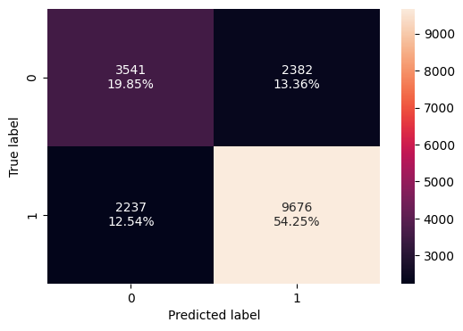

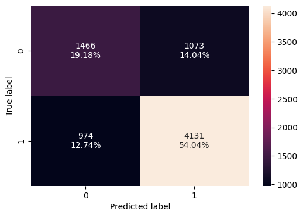

```python
#Tuning - Decision Tree with original dataset - Model10

# Define the parameter distribution
parameters = {'criterion':['gini','entropy'], 'max_depth': [5, 7, 9], 'min_samples_split': [10,20,30,40],'min_samples_leaf':[5,10,15,20],'min_impurity_decrease': [0.0001,0.001,0.01,0.1]}

# Initialize RandomizedSearchCV
model10 = RandomizedSearchCV(estimator=model1, param_distributions=parameters, n_iter=10, cv=3, n_jobs=-1, verbose=2, random_state=1)

# Fit RandomizedSearchCV
model10.fit(X_train, y_train)

# Print the best parameters
print(f'Best Parameters: {model10.best_params_}')

# Evaluate the tuned model
tuned_model10 = model10.best_estimator_
tuned_model10.fit(X_train, y_train)
y_pred = tuned_model10.predict(X_test)
f1 = f1_score(y_test, y_pred, average='weighted')
print(f'F1 Score: {f1 * 100:.2f}%')

#Get the training metrics
confmat(tuned_model10, X_train, y_train)
tuned_model10_train_df = model_performance(tuned_model10, X_train, y_train)
print(tuned_model10_train_df)

#Get the testing metrics
confmat(tuned_model10, X_test, y_test)
tuned_model10_test_df = model_performance(tuned_model10, X_test, y_test)
print(tuned_model10_test_df)
```

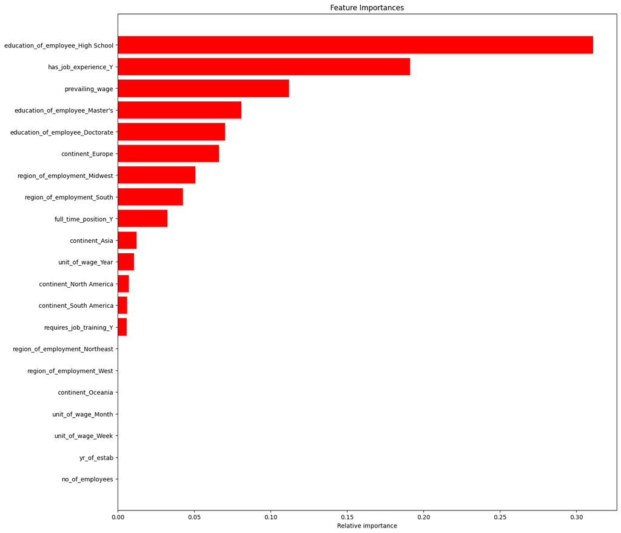

```python
#Tuned Model10 - Decision Tree + original dataset

feature_imp_plot(tuned_model10,X_train)
```

```
Best hyperparameters: {'n_estimators': 100, 'estimator__min_samples_split': 10, 'estimator__max_depth': 10}
F1 Score: 72.98%
   Accuracy    Recall  Precision        F1
0  0.782967  0.900109   0.799985  0.847099
   Accuracy    Recall  Precision       F1
0  0.740712  0.868168   0.771991  0.81726
```

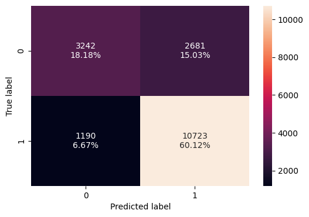

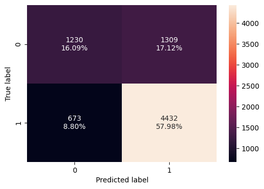

```python
#Tuning - Bagging Classifier with original dataset

# Initialize the base model (DecisionTreeClassifier)
base_model = DecisionTreeClassifier(random_state=42)

# Initialize BaggingClassifier with base model
bagging_clf = BaggingClassifier(base_model, random_state=42)

# Define parameter grid for RandomizedSearchCV
param_dist = {'n_estimators': [50,100,250,500],'estimator__max_depth':[None,10,20,30],'estimator__min_samples_split':[2,5,10,15]}

# Initialize RandomizedSearchCV
model11 = RandomizedSearchCV(bagging_clf, param_distributions=param_dist, n_iter=10, scoring='f1', cv=3, random_state=42, n_jobs=-1)

# Fit RandomizedSearchCV
model11.fit(X_train, y_train)

# Print the best parameters
print(f'Best hyperparameters: {model11.best_params_}')

# Evaluate the tuned model
tuned_model11 = model11.best_estimator_
tuned_model11.fit(X_train, y_train)
y_pred = tuned_model11.predict(X_test)
f1 = f1_score(y_test, y_pred, average='weighted')
print(f'F1 Score: {f1 * 100:.2f}%')


#Get the training metrics
confmat(tuned_model11, X_train, y_train)
tuned_model11_train_df = model_performance(tuned_model11, X_train, y_train)
print(tuned_model11_train_df)

#Get the testing metrics
confmat(tuned_model11, X_test, y_test)
tuned_model11_test_df = model_performance(tuned_model11, X_test, y_test)
print(tuned_model11_test_df)
```

```
F1 Score: 72.96%
   Accuracy    Recall  Precision        F1
0  0.768222  0.899857   0.784716  0.838351
   Accuracy    Recall  Precision        F1
0  0.743459  0.883252    0.76762  0.821386
```

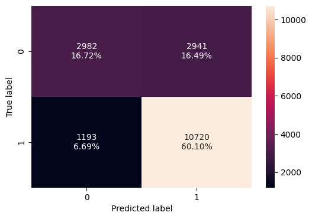

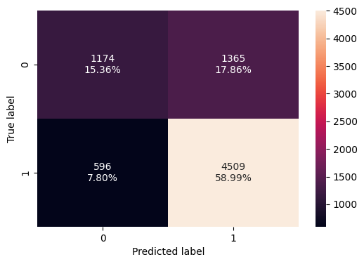

```python
#Tuning - Random Forest Classifier with original dataset

# Initialize the RandomForestClassifier
rf_clf = RandomForestClassifier(random_state=42)

# Define the parameter grid for RandomizedSearchCV
param_dist = {'n_estimators': [10,50,100,200,500], 'max_depth':[3,7,10], 'min_samples_split': [2, 5, 10, 15], 'min_samples_leaf': [1, 2, 4, 6, 8], 'max_features': ['sqrt', 'log2']}

# Initialize RandomizedSearchCV with F1 score as the scoring metric
model12 = RandomizedSearchCV(rf_clf, param_distributions=param_dist, n_iter=10, scoring='f1', cv=3, random_state=42, n_jobs=-1)

# Fit the model with RandomizedSearchCV
model12.fit(X_train, y_train)

# Evaluate the tuned model
tuned_model12 = model12.best_estimator_
tuned_model12.fit(X_train, y_train)
y_pred = tuned_model12.predict(X_test)
f1 = f1_score(y_test, y_pred, average='weighted')
print(f'F1 Score: {f1 * 100:.2f}%')


#Get the training metrics
confmat(tuned_model12, X_train, y_train)
tuned_model12_train_df = model_performance(tuned_model12, X_train, y_train)
print(tuned_model12_train_df)

#Get the testing metrics
confmat(tuned_model12, X_test, y_test)
tuned_model12_test_df = model_performance(tuned_model12, X_test, y_test)
print(tuned_model12_test_df)
```

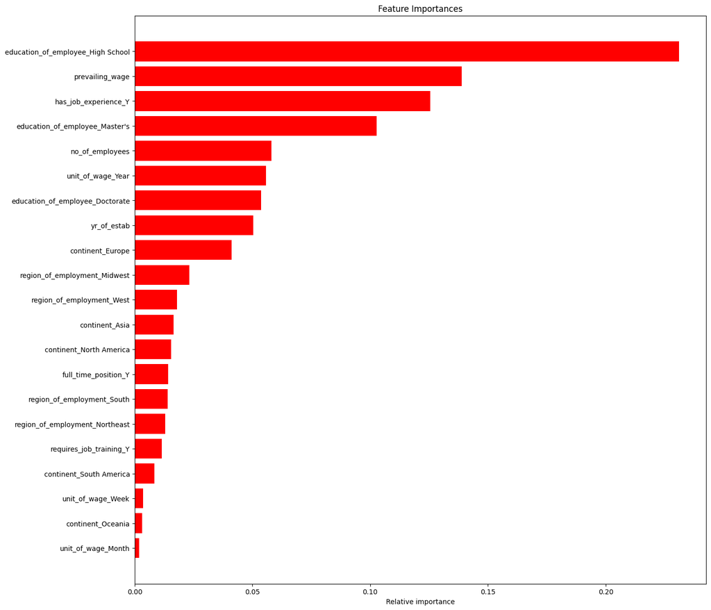

```python
#Tuned Model12 - Random forest Classifier + original dataset

feature_imp_plot(tuned_model12,X_train)
```

#### BOOSTING

1. Model13 - Adaboost using original data
2. Model14 - Adaboost using oversampled data
3. Model15 - Adaboost using undersampled data
4. Model16 - GradientBoost using original data
5. Mode117 - GradientBoost using oversampled data
6. Model18 - GradientBoost using undersampled data

Model13 - Adaboost using original data

```python
# Initialize the base model (DecisionTreeClassifier with max_depth=1 as weak learner) and Initialize AdaBoostClassifier with base model
base_model = DecisionTreeClassifier(max_depth=1, random_state=42)
model13 = AdaBoostClassifier(base_model, n_estimators=50, random_state=42)

# Train the model on the training data
model13.fit(X_train, y_train)
```

```
AdaBoostClassifier(estimator=DecisionTreeClassifier(max_depth=1,
                                                    random_state=42),
                   random_state=42)
```

|  | Accuracy | Recall | Precision | F1 |
| --- | --- | --- | --- | --- |
| 0 | 0.739684 | 0.88735 | 0.762039 | 0.819934 |

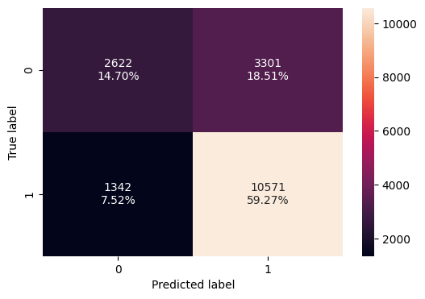

```python
#Get the training metrics
confmat(model13, X_train, y_train)

model13_train_df = model_performance(model13, X_train, y_train)
model13_train_df
```

[output not shown]

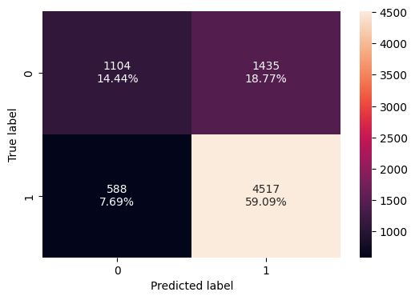

```python
#Get the testing metrics
confmat(model13, X_test, y_test)

model13_test_df = model_performance(model2, X_test, y_test)
model13_test_df
```

Model14 - Adaboost using oversampled data

```python
# Initialize the base model (DecisionTreeClassifier with max_depth=1 as weak learner) and Initialize AdaBoostClassifier with base model
base_model = DecisionTreeClassifier(max_depth=1, random_state=42)
model14 = AdaBoostClassifier(base_model, n_estimators=50, random_state=42)

# Train the model on the training data
model14.fit(X_train_OS, y_train_OS)
```

```
AdaBoostClassifier(estimator=DecisionTreeClassifier(max_depth=1,
                                                    random_state=42),
                   random_state=42)
```

|  | Accuracy | Recall | Precision | F1 |
| --- | --- | --- | --- | --- |
| 0 | 0.782045 | 0.882985 | 0.73467 | 0.802028 |

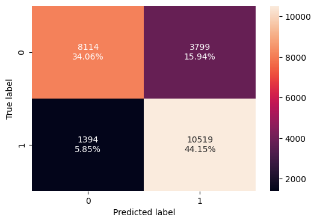

```python
#Get the training metrics
confmat(model14, X_train_OS, y_train_OS)

model14_train_df = model_performance(model14, X_train_OS, y_train_OS)
model14_train_df
```

|  | Accuracy | Recall | Precision | F1 |
| --- | --- | --- | --- | --- |
| 0 | 0.731162 | 0.874829 | 0.759266 | 0.812961 |

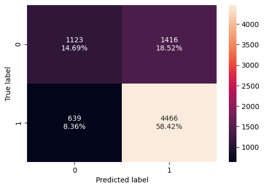

```python
#Get the testing metrics
confmat(model14, X_test, y_test)

model14_test_df = model_performance(model14, X_test, y_test)
model14_test_df
```

Model15 - Adaboost using undersampled data

```python
# Initialize the base model (DecisionTreeClassifier with max_depth=1 as weak learner) and Initialize AdaBoostClassifier with base model
base_model = DecisionTreeClassifier(max_depth=1, random_state=42)
model15 = AdaBoostClassifier(base_model, n_estimators=50, random_state=42)

# Train the model on the training data
model15.fit(X_train_US, y_train_US)
```

```
AdaBoostClassifier(estimator=DecisionTreeClassifier(max_depth=1,
                                                    random_state=42),
                   random_state=42)
```

|  | Accuracy | Recall | Precision | F1 |
| --- | --- | --- | --- | --- |
| 0 | 0.694918 | 0.7221 | 0.684868 | 0.702991 |

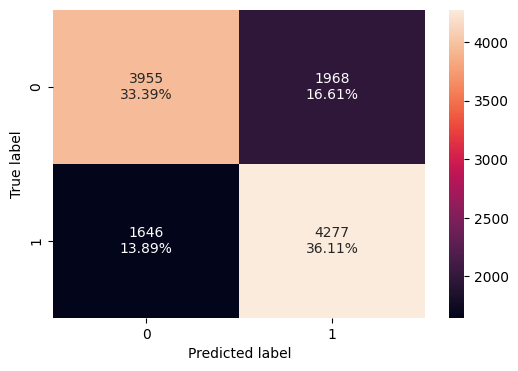

```python
#Get the training metrics
confmat(model15, X_train_US, y_train_US)

model15_train_df = model_performance(model15, X_train_US, y_train_US)
model15_train_df
```

|  | Accuracy | Recall | Precision | F1 |
| --- | --- | --- | --- | --- |
| 0 | 0.699503 | 0.720078 | 0.808979 | 0.761944 |

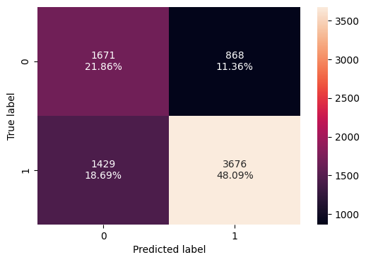

```python
#Get the testing metrics
confmat(model15, X_test, y_test)

model15_test_df = model_performance(model15, X_test, y_test)
model15_test_df
```

Model16 - GradientBoost using original data

```python
# Initialize GradientBoostingClassifier
model16 = GradientBoostingClassifier(random_state=42)
model16.fit(X_train, y_train)
```

```
GradientBoostingClassifier(random_state=42)
```

|  | Accuracy | Recall | Precision | F1 |
| --- | --- | --- | --- | --- |
| 0 | 0.758802 | 0.88374 | 0.783042 | 0.830349 |

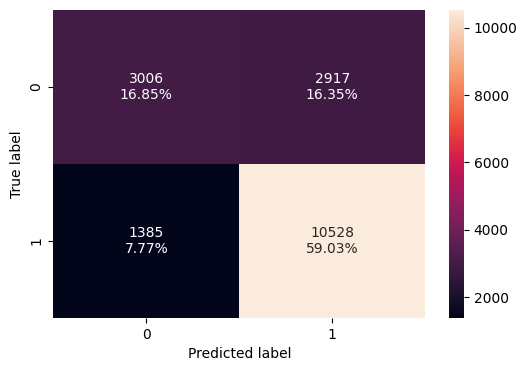

```python
#Get the training metrics
confmat(model16, X_train, y_train)

model16_train_df = model_performance(model16, X_train, y_train)
model16_train_df
```

|  | Accuracy | Recall | Precision | F1 |
| --- | --- | --- | --- | --- |
| 0 | 0.744767 | 0.876004 | 0.772366 | 0.820927 |

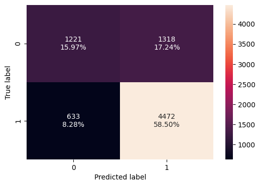

```python
#Get the testing metrics
confmat(model16, X_test, y_test)

model16_test_df = model_performance(model16, X_test, y_test)
model16_test_df
```

Mode117 - GradientBoost using oversampled data

```python
# Initialize GradientBoostingClassifier
model17 = GradientBoostingClassifier(random_state=42)
model17.fit(X_train_OS, y_train_OS)
```

```
GradientBoostingClassifier(random_state=42)
```

|  | Accuracy | Recall | Precision | F1 |
| --- | --- | --- | --- | --- |
| 0 | 0.798413 | 0.864602 | 0.763529 | 0.810928 |

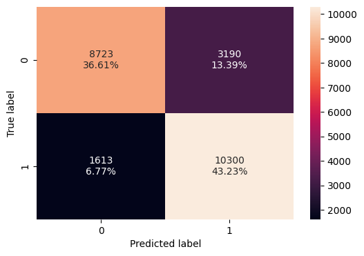

```python
#Get the training metrics
confmat(model17, X_train_OS, y_train_OS)

model17_train_df = model_performance(model17, X_train_OS, y_train_OS)
model17_train_df
```

|  | Accuracy | Recall | Precision | F1 |
| --- | --- | --- | --- | --- |
| 0 | 0.739011 | 0.854652 | 0.776887 | 0.813917 |

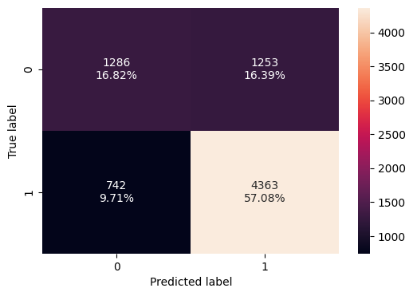

```python
#Get the testing metrics
confmat(model17, X_test, y_test)

model17_test_df = model_performance(model17, X_test, y_test)
model17_test_df
```

Model18 - GradientBoost using undersampled data

```python
# Initialize GradientBoostingClassifier
model18 = GradientBoostingClassifier(random_state=42)
model18.fit(X_train_US, y_train_US)
```

```
GradientBoostingClassifier(random_state=42)
```

|  | Accuracy | Recall | Precision | F1 |
| --- | --- | --- | --- | --- |
| 0 | 0.72286 | 0.729529 | 0.719927 | 0.724696 |

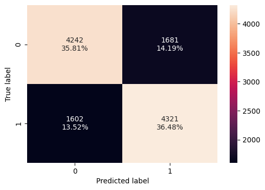

```python
#Get the training metrics
confmat(model18, X_train_US, y_train_US)

model18_train_df = model_performance(model18, X_train_US, y_train_US)
model18_train_df
```

|  | Accuracy | Recall | Precision | F1 |
| --- | --- | --- | --- | --- |
| 0 | 0.702904 | 0.71048 | 0.820588 | 0.761575 |

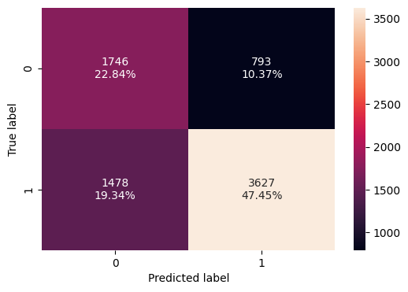

```python
#Get the testing metrics
confmat(model18, X_test, y_test)

model18_test_df = model_performance(model18, X_test, y_test)
model18_test_df
```

```python
## Training performance comparison

models_train_boosting = pd.concat([model13_train_df.T,model14_train_df.T,model15_train_df.T,model16_train_df.T,model17_train_df.T,model18_train_df.T], axis =1)
models_train_boosting.columns = ["AB_Orgdata", "AB_OSdata", "AB_USdata","GB_Orgdata", "GB_OSdata", "GB_USdata"]

print(models_train_boosting)
```

```
           AB_Orgdata  AB_OSdata  AB_USdata  GB_Orgdata  GB_OSdata  GB_USdata
Accuracy     0.739684   0.782045   0.694918    0.758802   0.798413   0.722860
Recall       0.887350   0.882985   0.722100    0.883740   0.864602   0.729529
Precision    0.762039   0.734670   0.684868    0.783042   0.763529   0.719927
F1           0.819934   0.802028   0.702991    0.830349   0.810928   0.724696
```

```python
## Testing performance comparison

models_test_boosting = pd.concat([model13_test_df.T,model14_test_df.T,model15_test_df.T,model16_test_df.T,model17_test_df.T,model18_test_df.T], axis =1)
models_test_boosting.columns = ["AB_Orgdata", "AB_OSdata", "AB_USdata","GB_Orgdata", "GB_OSdata", "GB_USdata"]

print(models_test_boosting)
```

[output not shown]

#### HyperParameter Tuning - Boosting

1. model19 - Adaboost Classifier + Original dataset + Hyper parameter tuning (RandomizedSearchCV)
2. model20 - GradientBoost Classifier + Original dataset + Hyper parameter tuning (RandomizedSearchCV)

```
F1 Score: 71.90%
   Accuracy   Recall  Precision        F1
0  0.739684  0.88735   0.762039  0.819934
   Accuracy    Recall  Precision        F1
0  0.735348  0.884819   0.758905  0.817039
```

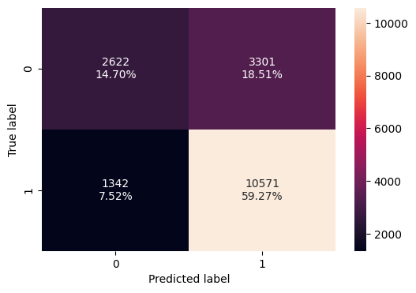

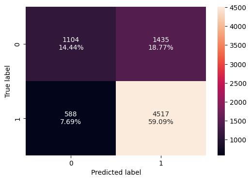

```python
#Tuning - Adaboost Classifier with original dataset - model 19

# Initialize the base model (DecisionTreeClassifier)
base_model = DecisionTreeClassifier(max_depth=1, random_state=42)  # Weak learner

# Initialize AdaBoostClassifier with base model
ada_boost_clf = AdaBoostClassifier(base_model, random_state=42)

# Define the parameter grid for RandomizedSearchCV
param_dist = {'n_estimators': [50, 150, 300], 'learning_rate': [1, 0.1, 0.5, 0.01]}

# Initialize RandomizedSearchCV with F1 score as the scoring metric
model19 = RandomizedSearchCV(ada_boost_clf, param_distributions=param_dist, n_iter=10, scoring='f1',cv=5, random_state=42, n_jobs=-1)

# Fit the model with RandomizedSearchCV
model19.fit(X_train, y_train)

# Get the best model found by the random search
tuned_model19 = model19.best_estimator_
tuned_model19.fit(X_train, y_train)
y_pred = tuned_model19.predict(X_test)
f1 = f1_score(y_test, y_pred, average='weighted')
print(f'F1 Score: {f1 * 100:.2f}%')

#Get the training metrics
confmat(tuned_model19, X_train, y_train)
tuned_model19_train_df = model_performance(tuned_model19, X_train, y_train)
print(tuned_model19_train_df)

#Get the testing metrics
confmat(tuned_model19, X_test, y_test)
tuned_model19_test_df = model_performance(tuned_model19, X_test, y_test)
print(tuned_model19_test_df)
```

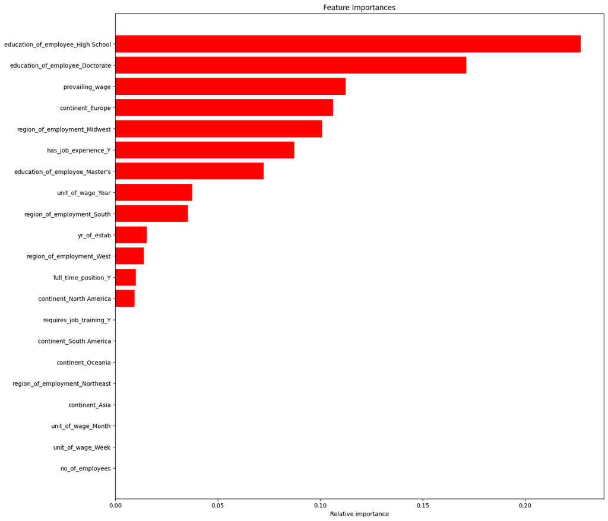

```python
#Tuned Model19 - AdaBoost + original dataset

feature_imp_plot(tuned_model19,X_train)
```

```
F1 Score: 72.38%
   Accuracy    Recall  Precision        F1
0   0.75527  0.903551   0.769957  0.831422
   Accuracy    Recall  Precision        F1
0  0.741497  0.895788   0.760013  0.822334
```

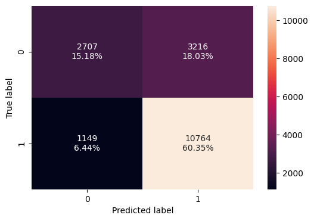

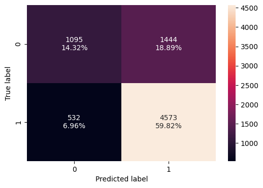

```python
# Tuning GradientBoost Classifier with original dataset - model 20

# Initialize GradientBoostingClassifier
gb_clf = GradientBoostingClassifier(random_state=42)

# Define the parameter grid for RandomizedSearchCV
param_dist = {'n_estimators': [50, 150, 300],'learning_rate':[1, 0.1, 0.5, 0.01], 'max_depth': [3,5,10], 'min_samples_split': [2, 5, 10, 15], 'min_samples_leaf': [1, 2, 4, 6, 8], 'max_features': ['sqrt', 'log2']}

# Initialize RandomizedSearchCV with F1 score as the scoring metric
model20 = RandomizedSearchCV(gb_clf, param_distributions=param_dist, n_iter=10, scoring='f1', cv=3, random_state=42, n_jobs=-1)

# Fit the model with RandomizedSearchCV
model20.fit(X_train, y_train)

# Get the best model found by the random search
tuned_model20 = model20.best_estimator_
tuned_model20.fit(X_train, y_train)
y_pred = tuned_model20.predict(X_test)
f1 = f1_score(y_test, y_pred, average='weighted')
print(f'F1 Score: {f1 * 100:.2f}%')

#Get the training metrics
confmat(tuned_model20, X_train, y_train)
tuned_model20_train_df = model_performance(tuned_model20, X_train, y_train)
print(tuned_model20_train_df)

#Get the testing metrics
confmat(tuned_model20, X_test, y_test)
tuned_model20_test_df = model_performance(tuned_model20, X_test, y_test)
print(tuned_model20_test_df)
```

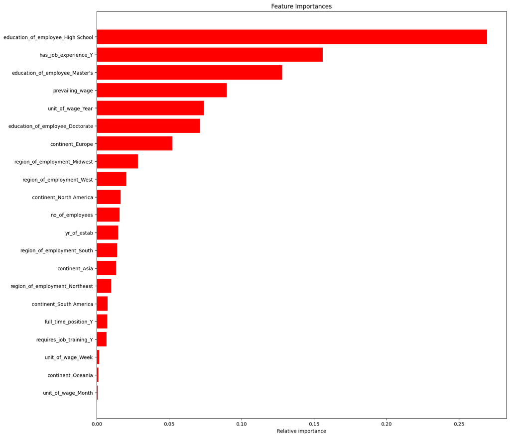

```python
#Tuned Model20 - Gradient Boost + original dataset

feature_imp_plot(tuned_model20,X_train)
```

#### Tuned Models Consolidation

1. Model 10 - Decision Tree
2. Model 11 - Bagging classifier
3. Model 12 - Random Forest
4. Model 19 - Adaboost Classifier
5. Model 20 - Gradient Boost CLassifier

```python
## Training performance comparison

tuned_models_train = pd.concat([tuned_model10_train_df.T,tuned_model11_train_df.T,tuned_model12_train_df.T,tuned_model19_train_df.T,tuned_model20_train_df.T], axis =1)
tuned_models_train.columns = ["DT_Orgdata", "Bag_Orgdata", "RF_Orgdata","AB_Orgdata", "GB_Orgdata"]

print(tuned_models_train)

## Testing performance comparison

tuned_models_test = pd.concat([tuned_model10_test_df.T,tuned_model11_test_df.T,tuned_model12_test_df.T,tuned_model19_test_df.T,tuned_model20_test_df.T], axis =1)
tuned_models_test.columns = ["DT_Orgdata", "Bag_Orgdata", "RF_Orgdata","AB_Orgdata", "GB_Orgdata"]

print(tuned_models_test)
```

```
           DT_Orgdata  Bag_Orgdata  RF_Orgdata  AB_Orgdata  GB_Orgdata
Accuracy     0.741029     0.782967    0.768222    0.739684    0.755270
Recall       0.812222     0.900109    0.899857    0.887350    0.903551
Precision    0.802455     0.799985    0.784716    0.762039    0.769957
F1           0.807309     0.847099    0.838351    0.819934    0.831422
           DT_Orgdata  Bag_Orgdata  RF_Orgdata  AB_Orgdata  GB_Orgdata
Accuracy     0.732208     0.740712    0.743459    0.735348    0.741497
Recall       0.809207     0.868168    0.883252    0.884819    0.895788
Precision    0.793812     0.771991    0.767620    0.758905    0.760013
F1           0.801436     0.817260    0.821386    0.817039    0.822334
```

**Observations and Buisiness Recommendations:**

Other Features to look at are as follows:

- Employees with yearly wage are preferred.
- Applications from Europe, Africa, and Asia have higher chances of visa certification
- Region of employment - Applications in the Mid-West region have more chances of visa approval.
- The requirement for the applicants who have passed high school is most in the South region, followed by Northeast region.
- The requirement for Bachelor's is mostly in South region, followed by West region.
- The requirement for Master's is most in Northeast region, followed by South region.
- The requirement for Doctorate's is mostly in West region, followed by Northeast region.
5. Visa Certifications can be **Denied** based on:
- High school degree employees have a higher chance of getting their visa denied.
- Continent - It has been observed that employees from South America and North America have higher chances of visa applications getting denied.
- Job Experience - Employees with no job experience have a higher chance of visa rejection.
- People with hourly wage are rarely granted visa.
- People from Island region have more denied visas.